# hw_03

Qi Yang

```r
library(tidyverse)
library(tidyr)
library(gapminder)
library(DT)
library(tsibble)
```

## 1.Task Option 2

#### Requirement: Get the maximum and minimum of GDP per capita for all continents.

1. Tibble

```r
gapminder %>%
  group_by(continent) %>%
  summarize(Max = max(gdpPercap),
            Country_max = country[gdpPercap == Max], # The country with the maximum GDP per cap
            Year_max = year[gdpPercap == Max], # The time when maximum GDP per cap appeared
            Min = min(gdpPercap),
            Country_min= country[gdpPercap == Min],  # The country with the minimum GDP per cap
            Year_min = year[gdpPercap == Min],) %>% # The time when minimum GDP per cap appeared
  rename(Continent = continent) %>%
DT::datatable()
```

|  | Continent | Max | Country_max | Year_max | Min | Country_min | Year_min |
| --- | --- | --- | --- | --- | --- | --- | --- |
| 1 | Africa | 21951.21176 | Libya | 1977 | 241.1658765 | Congo, Dem. Rep. | 2002 |
| 2 | Americas | 42951.65309 | United States | 2007 | 1201.637154 | Haiti | 2007 |
| 3 | Asia | 113523.1329 | Kuwait | 1957 | 331 | Myanmar | 1952 |
| 4 | Europe | 49357.19017 | Norway | 2007 | 973.5331948 | Bosnia and Herzegovina | 1952 |
| 5 | Oceania | 34435.36744 | Australia | 2007 | 10039.59564 | Australia | 1952 |

2. Plot

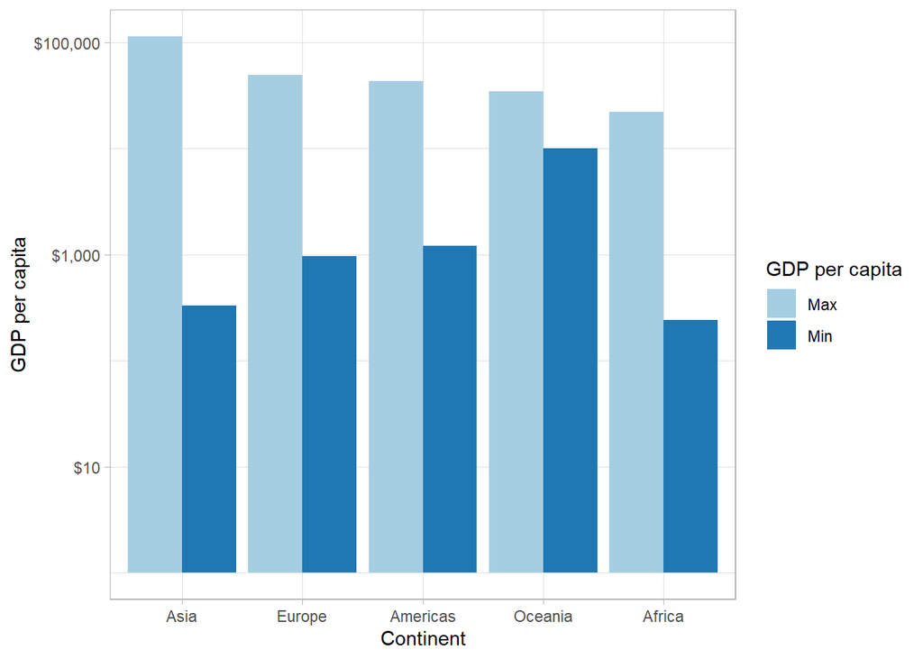

```r
gapminder %>%
  group_by(continent) %>%
  summarize(Max = max(gdpPercap),
            Min = min(gdpPercap),
            Max_forPlot = max(gdpPercap)) %>% # create a column for reordering bars in the plot below
  pivot_longer(cols      = c(Max, Min), # create a new column specifying whether the value is max or min for plotting
               names_to  = "Max_or_Min",
               values_to = "gdpPercap") %>%
  ggplot(aes(x= reorder(continent, -Max_forPlot), gdpPercap)) + # reordering, from high to low
    geom_bar(stat = "identity", aes(fill = Max_or_Min), position = "dodge") + # create two bars for a continent
     scale_y_log10("GDP per capita", labels = scales::dollar_format())+
     scale_x_discrete("Continent") +
     theme_light()+
     scale_fill_brewer(palette = "Paired", name = "GDP per capita") # use ColorBrewer to make it prettier
```

As a complement to the tibble above, this plot could help us see the comparison between the maximum and minimum GDP per capita in each continent more directly. The maximum GDP per capita of *Asia* is the highest, followed by *Europe, Americas, Oceania*, and *Africa*. In addition, it is interesting to see that *Oceania* tends to have the smallest gap between the highest and the lowest GDP per capita, while *Asia* has the biggest gap.

## 2.Task Option 3

#### Requirement: Look at the spread of GDP per capita within the continents.

1. Tibble

```r
gapminder %>%
  group_by(continent) %>%
  summarize(Range = paste(min(gdpPercap), max(gdpPercap), sep = " ~ "),
            Q1 = quantile(gdpPercap,0.25), # First quantile
            Q2 = quantile(gdpPercap,0.5), # Second quantile
            Q3 = quantile(gdpPercap,0.75), # Third quantile
            IQR = IQR(gdpPercap), # interquartile range
            VAR = var(gdpPercap), # variance
            SD = sd(gdpPercap)) %>%  # standard deviation
  rename(Continent = continent) %>%
  DT::datatable()
```

|  | Continent | Range | Q1 | Q2 | Q3 | IQR | VAR | SD |
| --- | --- | --- | --- | --- | --- | --- | --- | --- |
| 1 | Africa | 241.1658765 ~ 21951.21176 | 761.247009525 | 1192.138217 | 2377.41742175 | 1616.170412225 | 7997187.3079254 | 2827.92986262485 |
| 2 | Americas | 1201.637154 ~ 42951.65309 | 3427.77907225 | 5465.509853 | 7830.21041575 | 4402.4313435 | 40918591.1013692 | 6396.76411174972 |
| 3 | Asia | 331 ~ 113523.1329 | 1056.99322275 | 2646.786844 | 8549.25565425 | 7492.2624315 | 197272505.84641 | 14045.3731116838 |
| 4 | Europe | 973.5331948 ~ 49357.19017 | 7213.0850365 | 12081.749115 | 20461.3861625 | 13248.301126 | 87520019.6001875 | 9355.21349837552 |
| 5 | Oceania | 10039.59564 ~ 34435.36744 | 14141.8586975 | 17983.303955 | 22214.11711 | 8072.2584125 | 40436668.8728104 | 6358.98332068975 |

This tibble shows the **spread** of **GDP per capita** within the continents, which includes **range**, **quartiles (Q1, Q2, Q3)**, **interquartile range (IQR)**, **variance (VAR)** and **standard deviation (SD)**. Take *Africa* as an example: it has the smallest IQR and SD, indicating that the GDP per capita of African countries are closer to the mean value than other continents.

2. Plot

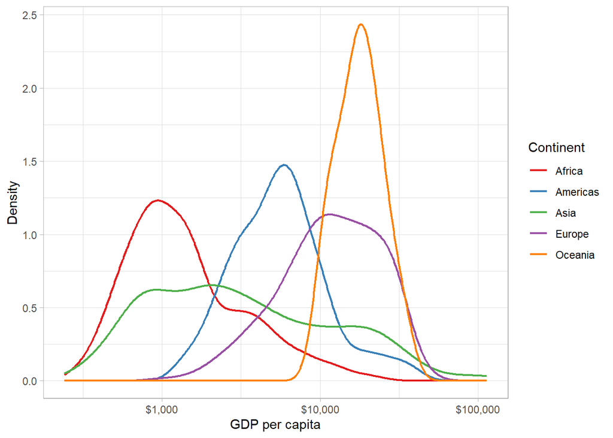

```r
ggplot(gapminder, aes(gdpPercap, color = continent)) +
  geom_line(stat = "density", size = 0.8) +
  scale_x_log10("GDP per capita", labels = scales::dollar_format(), )+
  scale_y_continuous("Density")+
  theme_light()+
  scale_color_brewer(palette="Set1", name = "Continent")
```

In order to complement the tibble above, this plot aims to show directly the **distribution** of **GDP per capita** for each continent. It provides visualization of the data in the tibble above, such as range and IQR. To discuss the plot in a more detailed way, for example, we can easily tell that *Oceania* seems to have more “concentrated” and higher values, while the values for *Asia* tend to be lower and spread further.

## 3.Task Option 5

#### Requirement: How is life expectancy changing over time on different continents?

1. Tibble

```r
gapminder %>%
  group_by(continent,year) %>%
  summarize(Min = min(lifeExp),
            Mean = mean(lifeExp),
            Max = max(lifeExp)) %>%
  rename(Continent = continent,
         Year = year) %>%
  DT::datatable()
```

|  | Continent | Year | Min | Mean | Max |
| --- | --- | --- | --- | --- | --- |
| 1 | Africa | 1952 | 30 | 39.1355 | 52.724 |
| 2 | Africa | 1957 | 31.57 | 41.2663461538462 | 58.089 |
| 3 | Africa | 1962 | 32.767 | 43.3194423076923 | 60.246 |
| 4 | Africa | 1967 | 34.113 | 45.3345384615385 | 61.557 |
| 5 | Africa | 1972 | 35.4 | 47.4509423076923 | 64.274 |
| 6 | Africa | 1977 | 36.788 | 49.5804230769231 | 67.064 |
| 7 | Africa | 1982 | 38.445 | 51.5928653846154 | 69.885 |
| 8 | Africa | 1987 | 39.906 | 53.3447884615385 | 71.913 |
| 9 | Africa | 1992 | 23.599 | 53.6295769230769 | 73.615 |
| 10 | Africa | 1997 | 36.087 | 53.5982692307692 | 74.772 |

[output cut: 50 more lines]

This tibble shows how the **minimum, mean** and **maximum** values of **life expectancy** has changed over **time** on each continent. There is a bunch of data, and we may guess that life expectancy goes up with time generally across the globe. To see the trend more clearly and quickly, we can use the plot below.

2. Plot

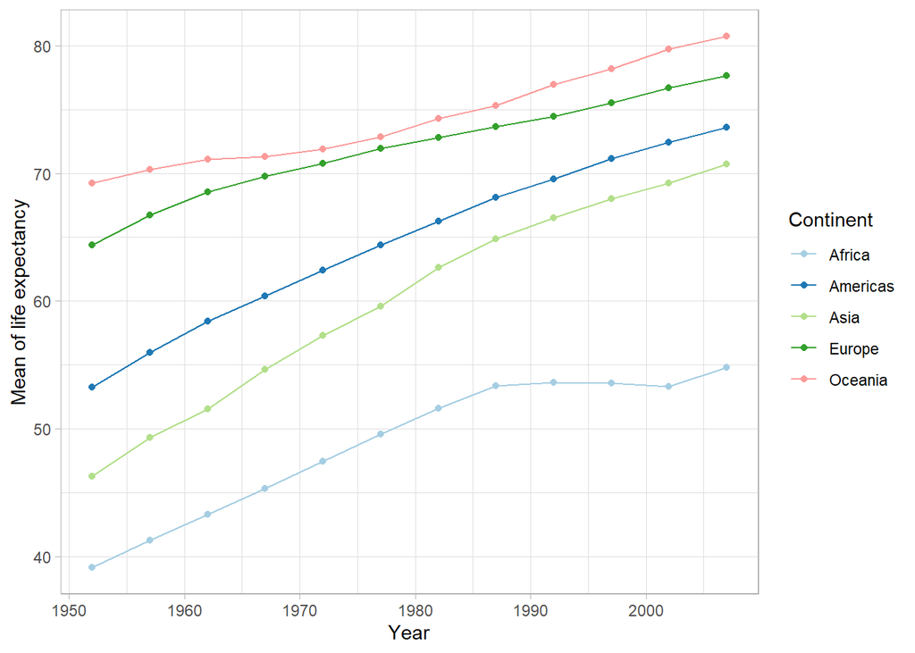

```r
gapminder %>%
  group_by(continent, year) %>%
  summarize(min = min(lifeExp),
            mean = mean(lifeExp),
            max = max(lifeExp)) %>%
  ggplot(aes(year, mean, colour = continent)) +
  geom_line()+
  geom_point()+
  scale_x_continuous("Year")+
  scale_y_continuous("Mean of life expectancy")+
  theme_light()+
  scale_color_brewer(palette="Paired", name = "Continent")
```

The plot shows how the **mean** value of **life expectancy** of each continent changes over **time**, supporting our guess that people tend to live longer with time going on. However, in the case of *Africa*, life expectancy dropped from 1990 to 2005. We can also see that the growing speed was not the same for different continents and in different times, for instance, the value for *Oceania* grew slowly from 1960 to 1970.

## Optional Exercise

#### Requirement: Get table and figure side-by-side.

My tibbles above seem to be too wide to achieve this task, so I just modified the tibble from Task Option 2 and used the corresponding plot.

| Continent | Max | Year_max | Min | Year_min |
| --- | --- | --- | --- | --- |
| Africa | 21951.21 | 1977 | 241.1659 | 2002 |
| Americas | 42951.65 | 2007 | 1201.6372 | 2007 |
| Asia | 113523.13 | 1957 | 331.0000 | 1952 |
| Europe | 49357.19 | 2007 | 973.5332 | 1952 |
| Oceania | 34435.37 | 2007 | 10039.5956 | 1952 |

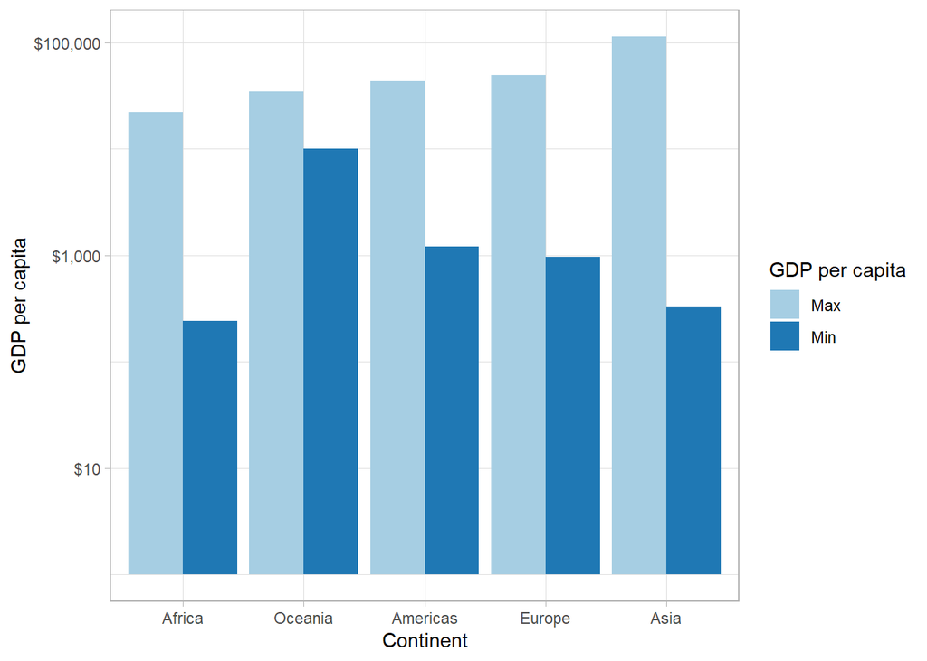